# Analyzing Individual BGG Users

Phil Henrickson

2021-12-07

Load previously queried training and test data from the local layer.

Set function for displaying probabilities

Fit models and analyze collection for **GOBbluth89**.

## Games in Collection

How many games has the user owned/played in the training set (games prior to 2020)?

```
## # A tibble: 1 × 3
##   username   games_owned games_played
##   <chr>            <dbl>        <dbl>
## 1 GOBbluth89          57            0
```

## Coefficients for GOBbluth89

Examine coefficients from the trained model.

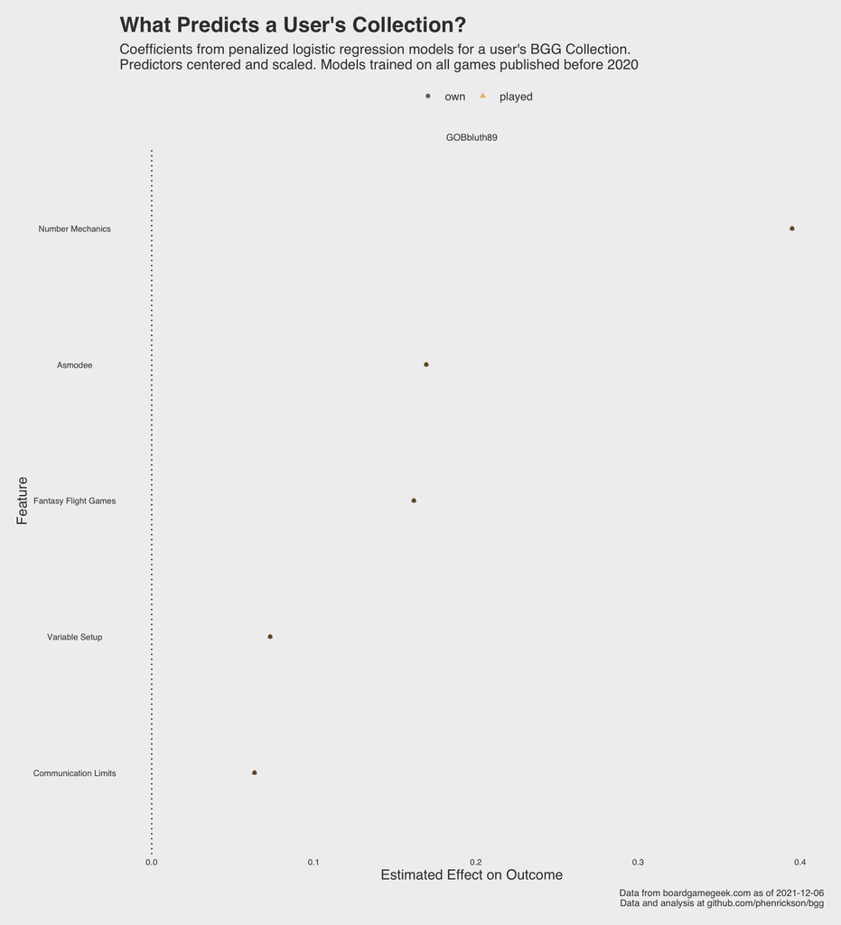

## Visualizing Predictors for GOBbluth89’s Collection

Examine density of most important features for predicting whether user owns a game.

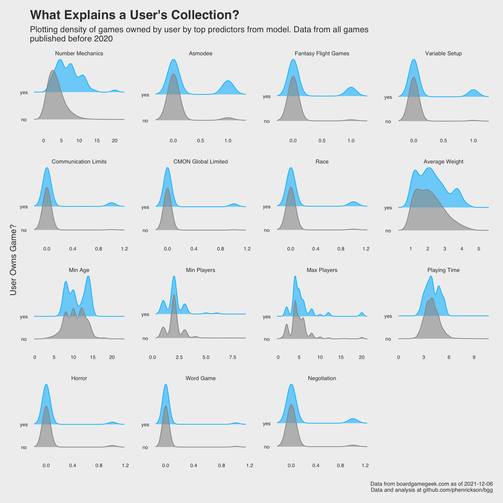

Binary predictors can be difficult to see with this visualization, so we can also directly examine the percentage of games that a user owns with and without binary predictors.

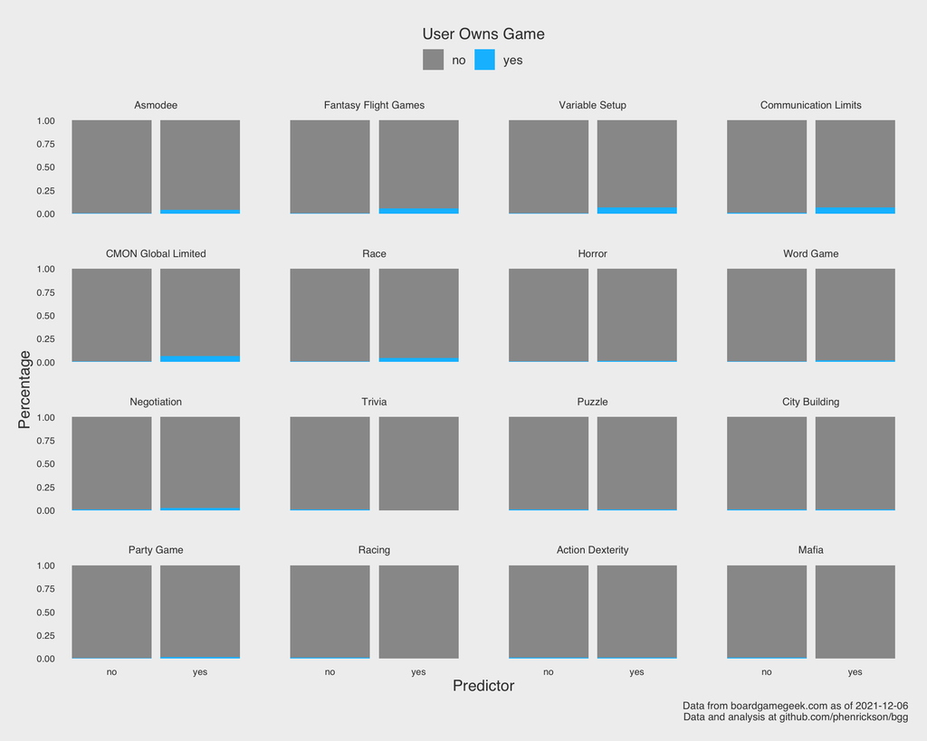

## Assessment

Examine separation plot for training set (cross validated predictions).

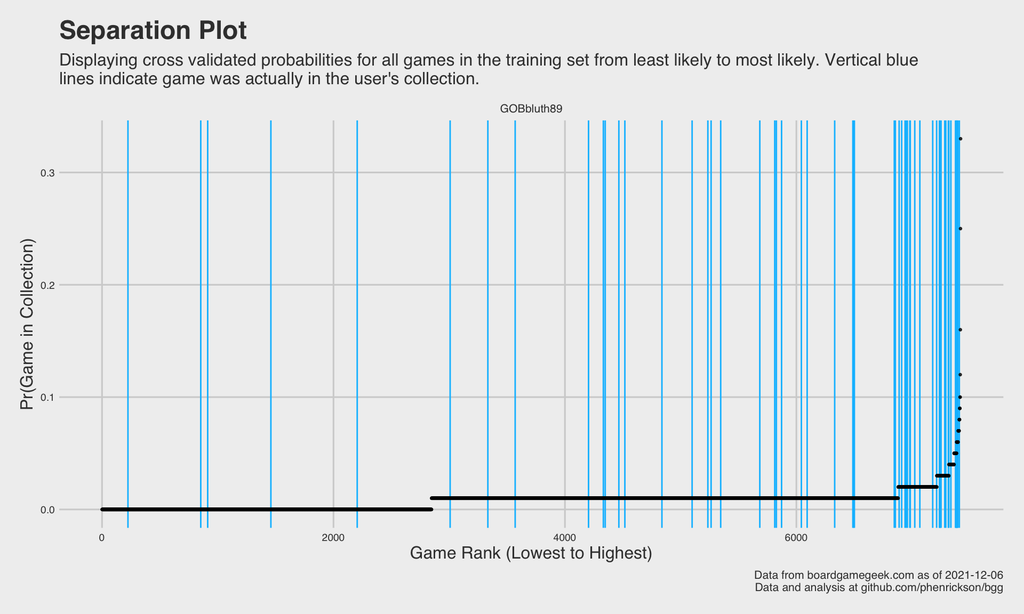

Formally assess how well the model did in resampling.

| outcome_type | .metric | .estimator | .estimate |
| --- | --- | --- | --- |
| own | roc_auc | binary | 0.829 |
| played | roc_auc | binary | 0.829 |

## Predicted Games in Collection from Training

Examine top games from resampling.

Top Overall Games for User from Resampling

| username | yearpublished | game_id | name | pred_played | pred_own | actual_played | actual_own |
| --- | --- | --- | --- | --- | --- | --- | --- |
| GOBbluth89 | 2018 | 205896 | Rising Sun | 0.33 | 0.33 | 0 | 0 |
| GOBbluth89 | 2017 | 233078 | Twilight Imperium: Fourth Edition | 0.25 | 0.25 | 0 | 0 |
| GOBbluth89 | 2008 | 37111 | Battlestar Galactica: The Board Game | 0.16 | 0.16 | 0 | 0 |
| GOBbluth89 | 2000 | 478 | Citadels | 0.12 | 0.12 | 0 | 0 |
| GOBbluth89 | 2017 | 221805 | Breaking Bad: The Board Game | 0.10 | 0.10 | 0 | 0 |
| GOBbluth89 | 1976 | 3083 | Submarine | 0.10 | 0.10 | 0 | 0 |
| GOBbluth89 | 2012 | 104710 | Wiz-War (Eighth Edition) | 0.09 | 0.09 | 0 | 0 |
| GOBbluth89 | 2012 | 123096 | Space Cadets | 0.09 | 0.09 | 0 | 0 |
| GOBbluth89 | 2012 | 104162 | Descent: Journeys in the Dark (Second Edition) | 0.09 | 0.09 | 0 | 0 |
| GOBbluth89 | 2018 | 244711 | Newton | 0.08 | 0.08 | 0 | 0 |
| GOBbluth89 | 2017 | 174430 | Gloomhaven | 0.08 | 0.08 | 1 | 1 |
| GOBbluth89 | 2015 | 175878 | 504 | 0.08 | 0.08 | 0 | 0 |
| GOBbluth89 | 2016 | 205059 | Mansions of Madness: Second Edition | 0.08 | 0.08 | 0 | 0 |
| GOBbluth89 | 1973 | 2995 | Sniper! | 0.07 | 0.07 | 0 | 0 |
| GOBbluth89 | 2015 | 181530 | Runebound (Third Edition) | 0.07 | 0.07 | 0 | 0 |
| GOBbluth89 | 2011 | 96848 | Mage Knight Board Game | 0.07 | 0.07 | 0 | 0 |
| GOBbluth89 | 2011 | 70919 | Takenoko | 0.07 | 0.07 | 0 | 0 |
| GOBbluth89 | 2019 | 285984 | Last Bastion | 0.07 | 0.07 | 0 | 0 |
| GOBbluth89 | 2004 | 9609 | War of the Ring | 0.07 | 0.07 | 0 | 0 |
| GOBbluth89 | 2019 | 266507 | Clank!: Legacy – Acquisitions Incorporated | 0.07 | 0.07 | 0 | 0 |
| GOBbluth89 | 2014 | 156129 | Deception: Murder in Hong Kong | 0.07 | 0.07 | 0 | 0 |
| GOBbluth89 | 2011 | 102548 | Dungeon Fighter | 0.07 | 0.07 | 0 | 0 |
| GOBbluth89 | 1983 | 1608 | Ambush! | 0.06 | 0.06 | 0 | 0 |
| GOBbluth89 | 2010 | 25292 | Merchants & Marauders | 0.06 | 0.06 | 0 | 0 |
| GOBbluth89 | 2019 | 276025 | Maracaibo | 0.06 | 0.06 | 0 | 0 |
| GOBbluth89 | 2005 | 15987 | Arkham Horror | 0.06 | 0.06 | 1 | 1 |
| GOBbluth89 | 2005 | 12493 | Twilight Imperium: Third Edition | 0.06 | 0.06 | 1 | 1 |
| GOBbluth89 | 2010 | 65200 | Asteroyds | 0.06 | 0.06 | 0 | 0 |
| GOBbluth89 | 2013 | 127024 | Room 25 | 0.06 | 0.06 | 0 | 0 |
| GOBbluth89 | 2012 | 122515 | Keyflower | 0.06 | 0.06 | 0 | 0 |

[output cut: 70 more lines]

### Most and Least Likely Games

What game does the model think GOBbluth89 is **most likely to own** that is **not** in their collection?

| username | yearpublished | game_id | name | pred_own |
| --- | --- | --- | --- | --- |
| GOBbluth89 | 2018 | 205896 | Rising Sun | 0.33 |

What game does the model think GOBbluth89 is **least likely to own** that **is** in their collection?

| username | yearpublished | game_id | name | pred_own |
| --- | --- | --- | --- | --- |
| GOBbluth89 | 2018 | 247367 | Air, Land & Sea | 0 |

### Top Games by Year

Top 25 games most likely to be owned by the user in each year, highlighting in blue the games that the user has owned/played.

| rank | 2012 | 2013 | 2014 | 2015 | 2016 | 2017 | 2018 | 2019 |
| --- | --- | --- | --- | --- | --- | --- | --- | --- |
| 1 | Wiz-War (Eighth Edition) | Room 25 | Deception: Murder in Hong Kong | 504 | Mansions of Madness: Second Edition | Twilight Imperium: Fourth Edition | Rising Sun | Last Bastion |
| 2 | Space Cadets | Lewis & Clark: The Expedition | Spyfall | Runebound (Third Edition) | Black Orchestra | Breaking Bad: The Board Game | Newton | Clank!: Legacy – Acquisitions Incorporated |
| 3 | Descent: Journeys in the Dark (Second Edition) | Impulse | Spurs: A Tale in the Old West | Blood Rage | Game of Thrones: The Iron Throne | Gloomhaven | Heroes of Terrinoth | Maracaibo |
| 4 | Keyflower | BattleLore: Second Edition | Star Wars: Imperial Assault | The Grizzled | Yokohama | This War of Mine: The Board Game | Arkham Horror (Third Edition) | The Lord of the Rings: Journeys in Middle-Earth |
| 5 | Archipelago | Warhammer: Diskwars | Sons of Anarchy: Men of Mayhem | ...and then, we held hands. | Codenames: Pictures | Fallout | The World of SMOG: Rise of Moloch | The Magnificent |
| 6 | Robinson Crusoe: Adventures on the Cursed Island | Eldritch Horror | Five Tribes | Forbidden Stars | Codenames: Deep Undercover | Civilization: A New Dawn | Narcos: The Board Game | Tainted Grail: The Fall of Avalon |
| 7 | The Manhattan Project | Concordia | DungeonQuest Revised Edition | Warhammer Quest: The Adventure Card Game | The Oregon Trail Card Game | Magic Maze | The Grizzled: Armistice Edition | One Key |
| 8 | War of the Ring: Second Edition | Dungeon Twister: The Card Game | Witness | The Voyages of Marco Polo | Inis | The Godfather: Corleone's Empire | Cosmic Encounter: 42nd Anniversary Edition | Yukon Airways |
| 9 | Merchant of Venus (Second Edition) | City of Remnants | Deus | Mysterium | Hit Z Road | Runewars Miniatures Game | A Song of Ice & Fire: Tabletop Miniatures Game – Stark vs Lannister Starter Set | Era: Medieval Age |
| 10 | Smash Up | Relic | The Witcher Adventure Game | Mission: Red Planet (Second Edition) | Star Wars: Rebellion | LYNGK | Gen7: A Crossroads Game | Black Angel |
| 11 | Rex: Final Days of an Empire | Legacy: The Testament of Duke de Crecy | Colt Express | Fury of Dracula (Third/Fourth Edition) | Dream Home | Smash Up: What Were We Thinking? | Fireball Island: The Curse of Vul-Kar | Nevsky: Teutons and Rus in Collision 1240-1242 |
| 12 | Zombicide | 1775: Rebellion | Dead of Winter: A Crossroads Game | Raptor | Islebound | Codenames: Duet | Gizmos | KeyForge: Age of Ascension |
| 13 | Bolt Action | Patchistory | Akrotiri | T.I.M.E Stories | Agricola (Revised Edition) | Pendragon: The Fall of Roman Britain | Street Masters | The Isle of Cats |
| 14 | Terra Mystica | BANG! The Dice Game | Patchwork | Burgle Bros. | Citadels | Whitehall Mystery | Teotihuacan: City of Gods | Barrage |
| 15 | Game of Thrones: The Card Game | Tajemnicze Domostwo | Abyss | Risk: Europe | New Angeles | Photosynthesis | Shadows: Amsterdam | Obscurio |
| 16 | Legends of Andor | LEADERS: The Combined Strategy Game | Black Fleet | Mombasa | DOOM: The Board Game | Gaia Project | Muse: Awakenings | Hellenica: Story of Greece |
| 17 | Spartacus: A Game of Blood and Treachery | Zombicide Season 2: Prison Outbreak | La Granja | The King Is Dead | Terraforming Mars | Spirit Island | Renegade | Tiny Towns |
| 18 | Il Vecchio | Forbidden Desert | Shadows of Malice | XCOM: The Board Game | Scythe | Clans of Caledonia | Pandemic: Fall of Rome | Tapestry |
| 19 | Clash of Cultures | Bruxelles 1893 | Hyperborea | Grand Austria Hotel | Smash Up: Cease and Desist | Codenames: Marvel | Star Wars: Legion | Hearts and Minds: Vietnam 1965-1975 (Third Edition) |
| 20 | Kairo | Dungeon Command: Blood of Gruumsh | Xia: Legends of a Drift System | Codenames | Exceed Fighting System | Summit: The Board Game | Kero | Peloponnesian War |
| 21 | Divinare | Band of Brothers: Ghost Panzer | Praetor | Zombicide Season 3: Rue Morgue | Aventuria: Adventure Card Game | Mountains of Madness | The Order of Vampire Hunters | Cloudspire |
| 22 | Winter Tales | No Retreat!: The North African Front | Dogs of War | Watson & Holmes | Falling Sky: The Gallic Revolt Against Caesar | The Shipwreck Arcana | Lords of Hellas | Star Wars: Outer Rim |
| 23 | The Last Banquet | Crusade and Revolution: The Spanish Civil War, 1936-1939 | Legendary Encounters: An Alien Deck Building Game | Aye, Dark Overlord! The Green Box | Tyrants of the Underdark | Aristeia! | Root | Middara: Unintentional Malum – Act 1 |
| 24 | Exodus: Proxima Centauri | Sedition Wars: Battle for Alabaster | Istanbul | Between Two Cities | Aeon's End | Mythic Battles: Pantheon | Coimbra | Call to Adventure |
| 25 | Libertalia | Invaders | Sheriff of Nottingham | Drakon (Fourth Edition) | Clank!: A Deck-Building Adventure | Pulsar 2849 | Everdell | Sierra West |

### Interactive Table

Interactive table for predictions from resampling.

|  | username | yearpublished | rank | game_id | name | pred_played | pred_own | actual_played | actual_own |
| --- | --- | --- | --- | --- | --- | --- | --- | --- | --- |
| 1 | GOBbluth89 | 1900 | 653 | 171 | Chess | 0.01 | 0.01 | 0 | 0 |
| 2 | GOBbluth89 | 1900 | 810 | 1602 | The Royal Game of Ur | 0.01 | 0.01 | 0 | 0 |
| 3 | GOBbluth89 | 1900 | 811 | 2083 | Checkers | 0.01 | 0.01 | 0 | 0 |
| 4 | GOBbluth89 | 1900 | 814 | 2397 | Backgammon | 0.01 | 0.01 | 0 | 0 |
| 5 | GOBbluth89 | 1900 | 999 | 10213 | Fox and Geese | 0.01 | 0.01 | 0 | 0 |
| 6 | GOBbluth89 | 1900 | 1000 | 11582 | Schnapsen | 0.01 | 0.01 | 0 | 0 |
| 7 | GOBbluth89 | 1900 | 1175 | 7316 | Bingo | 0.01 | 0.01 | 0 | 0 |
| 8 | GOBbluth89 | 1900 | 1865 | 2173 | 4 Player Chess | 0.01 | 0.01 | 0 | 0 |
| 9 | GOBbluth89 | 1900 | 2166 | 38950 | Halma | 0.01 | 0.01 | 0 | 0 |
| 10 | GOBbluth89 | 1900 | 2759 | 4505 | Tarot | 0.01 | 0.01 | 0 | 0 |

[output cut: 7409 more lines]

## Predicted Games in Collection 2020 and On

Examine the top games for the test set.

Top Predicted Games for User, 2020 and On

| username | yearpublished | game_id | name | rank | own | played |
| --- | --- | --- | --- | --- | --- | --- |
| GOBbluth89 | 2020 | 291457 | Gloomhaven: Jaws of the Lion | 1 | 0.19 | 0.19 |
| GOBbluth89 | 2020 | 292333 | Cowboys II: Cowboys & Indians Edition | 2 | 0.11 | 0.11 |
| GOBbluth89 | 2020 | 256317 | Guild Master | 3 | 0.06 | 0.06 |
| GOBbluth89 | 2020 | 308652 | Age of Dogfights: WW1 | 4 | 0.06 | 0.06 |
| GOBbluth89 | 2020 | 184267 | On Mars | 5 | 0.05 | 0.05 |
| GOBbluth89 | 2020 | 295905 | Cosmic Frog | 6 | 0.05 | 0.05 |
| GOBbluth89 | 2020 | 299179 | Chancellorsville 1863 | 7 | 0.05 | 0.05 |
| GOBbluth89 | 2020 | 319966 | The King Is Dead: Second Edition | 8 | 0.04 | 0.04 |
| GOBbluth89 | 2020 | 256940 | Krosmaster: Blast | 9 | 0.04 | 0.04 |
| GOBbluth89 | 2020 | 298572 | Cosmic Encounter Duel | 10 | 0.04 | 0.04 |
| GOBbluth89 | 2020 | 302723 | Forgotten Waters | 11 | 0.03 | 0.03 |
| GOBbluth89 | 2020 | 293889 | Fallout Shelter: The Board Game | 12 | 0.03 | 0.03 |
| GOBbluth89 | 2020 | 301767 | Mysterium Park | 13 | 0.03 | 0.03 |
| GOBbluth89 | 2020 | 288539 | The Jaws of Victory: Battle of Korsun-Cherkassy Pocket – January/February 1944 | 14 | 0.03 | 0.03 |
| GOBbluth89 | 2020 | 312965 | Hogs of War: The Miniatures Game | 15 | 0.03 | 0.03 |
| GOBbluth89 | 2020 | 315196 | Dungeons & Dragons: Adventure Begins | 16 | 0.03 | 0.03 |
| GOBbluth89 | 2020 | 316554 | Dune: Imperium | 17 | 0.03 | 0.03 |
| GOBbluth89 | 2020 | 246900 | Eclipse: Second Dawn for the Galaxy | 18 | 0.03 | 0.03 |
| GOBbluth89 | 2020 | 306481 | Tawantinsuyu: The Inca Empire | 19 | 0.03 | 0.03 |
| GOBbluth89 | 2020 | 306735 | Under Falling Skies | 20 | 0.03 | 0.03 |
| GOBbluth89 | 2020 | 293579 | Totemic | 21 | 0.02 | 0.02 |
| GOBbluth89 | 2020 | 300327 | The Castles of Tuscany | 22 | 0.02 | 0.02 |
| GOBbluth89 | 2020 | 299592 | Beez | 23 | 0.02 | 0.02 |
| GOBbluth89 | 2020 | 301919 | Pandemic: Hot Zone – North America | 24 | 0.02 | 0.02 |
| GOBbluth89 | 2020 | 236713 | Sea of Plunder | 25 | 0.02 | 0.02 |
| GOBbluth89 | 2020 | 284742 | Honey Buzz | 26 | 0.02 | 0.02 |
| GOBbluth89 | 2020 | 286021 | Free Market: NYC | 27 | 0.02 | 0.02 |
| GOBbluth89 | 2020 | 294652 | By Stealth and Sea | 28 | 0.02 | 0.02 |
| GOBbluth89 | 2020 | 299252 | Here to Slay | 29 | 0.02 | 0.02 |
| GOBbluth89 | 2020 | 302840 | Carcata | 30 | 0.02 | 0.02 |

[output cut: 179 more lines]

Interactive table for 2020 and On

|  | username | yearpublished | game_id | name | rank | own | played |
| --- | --- | --- | --- | --- | --- | --- | --- |
| 1 | GOBbluth89 | 2020 | 291457 | Gloomhaven: Jaws of the Lion | 1 | 0.19 | 0.19 |
| 2 | GOBbluth89 | 2022 | 331106 | The Witcher: Old World | 2 | 0.13 | 0.13 |
| 3 | GOBbluth89 | 2020 | 292333 | Cowboys II: Cowboys &amp; Indians Edition | 3 | 0.11 | 0.11 |
| 4 | GOBbluth89 | 2021 | 298102 | Roll Camera!: The Filmmaking Board Game | 4 | 0.1 | 0.1 |
| 5 | GOBbluth89 | 2022 | 317511 | Tindaya | 5 | 0.08 | 0.08 |
| 6 | GOBbluth89 | 2022 | 295770 | Frosthaven | 6 | 0.08 | 0.08 |
| 7 | GOBbluth89 | 2020 | 256317 | Guild Master | 7 | 0.06 | 0.06 |
| 8 | GOBbluth89 | 2020 | 308652 | Age of Dogfights: WW1 | 8 | 0.06 | 0.06 |
| 9 | GOBbluth89 | 2021 | 285967 | Ankh: Gods of Egypt | 9 | 0.06 | 0.06 |
| 10 | GOBbluth89 | 2020 | 184267 | On Mars | 10 | 0.05 | 0.05 |

[output cut: 1581 more lines]